# WasteWater Analysis 2.0 with N2

Steve Goldstein and Marlin Lee

To give some measure of the variation of the data we look at the high frequency data. It shows that outliers often clump with the other filter replicates

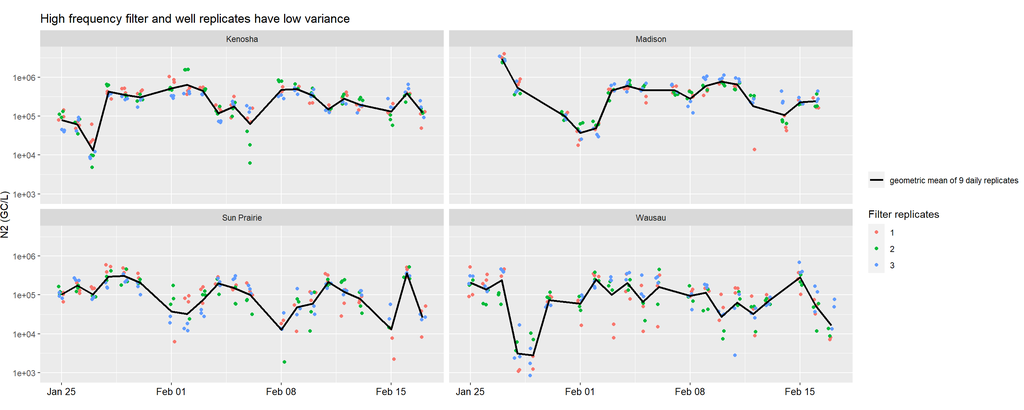

```r
N2PlotGraphic <- ggplot()+
  geom_jitter(aes(x=Date,y=N2,color=`Filter replicates`),width=.2,data=LimitedHFData)+
  geom_line(aes(x=Date,y=N2,linetype ="geometric mean of 9 daily replicates"),
            size=1,data=meanOfN2)+
  facet_wrap(~Site)+
  scale_y_log10()
```

PMMoV and percent bovine coronavirus recovery use is unclear. Unusual PMMoV and percent BCoV do not seem to relate to unusual N2 values.

```r
PMMoVUseDF=LimitedHFData%>%
  mutate(`PMMoV Level`=ifelse(PMMoV<1*10^7,"Low","Medium"))%>%
  mutate(`PMMoV Level`=ifelse(PMMoV>1*10^8,"High",`PMMoV Level`))%>%
  mutate(`PMMoV Level`=factor(`PMMoV Level`,levels=c("High","Medium","Low")))
```

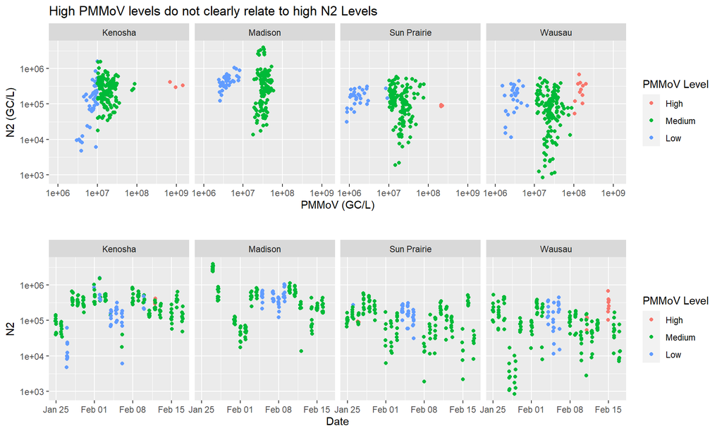

```r
BCoVUseDF=LimitedHFData%>%
  filter(N2<2e6)%>%
  mutate(`% BCoV Rec`=ifelse(Pct_BCoV<.5,"Low","Medium"))%>%
  mutate(`% BCoV Rec`=ifelse(Pct_BCoV>10,"High",`% BCoV Rec`))%>%
  mutate(`% BCoV Rec`=factor(`% BCoV Rec`,levels=c("High","Medium","Low")))
```

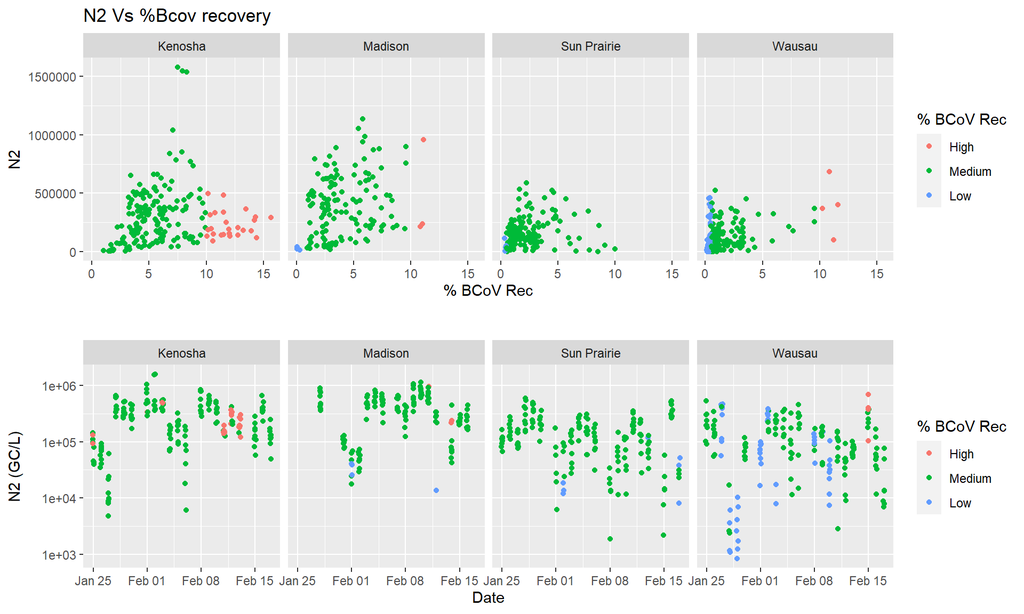

Due to the large variations of the N2 concentration we have tried to create a smoothed version of the data set that captures the underlying shifts of the data. Below is our best attempt at smoothing the N2 concentration data. It shows relation to case data given the spread of shedding of N2. This relationship holds for N2 as well.

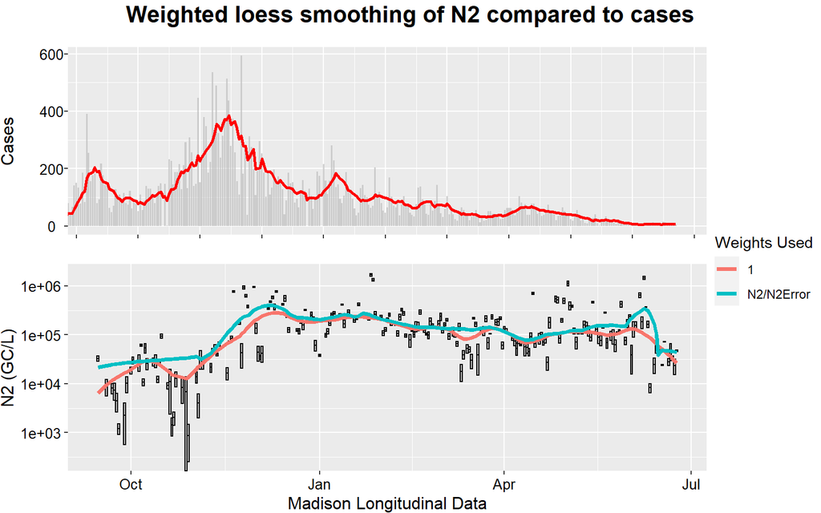

```r
N2Plot <- LoessSmoothPlot(SiteS="Madison",Span=.1,min=0,max=120,weights=c("Constant","N/NSE"),
                          Title = F,FullLim=F,SiteLab=F)

CasePlot <- CasePlotMaking("Madison")
```

To use standard Error measurements in our smoothing we needed to have it be an unbiased estimate given the concentration. A strong correlation between N2 and N2Error means it needs to be controlled for. Using standard error normalized by N2 gave a meaningful measurement of the consistency of the data.

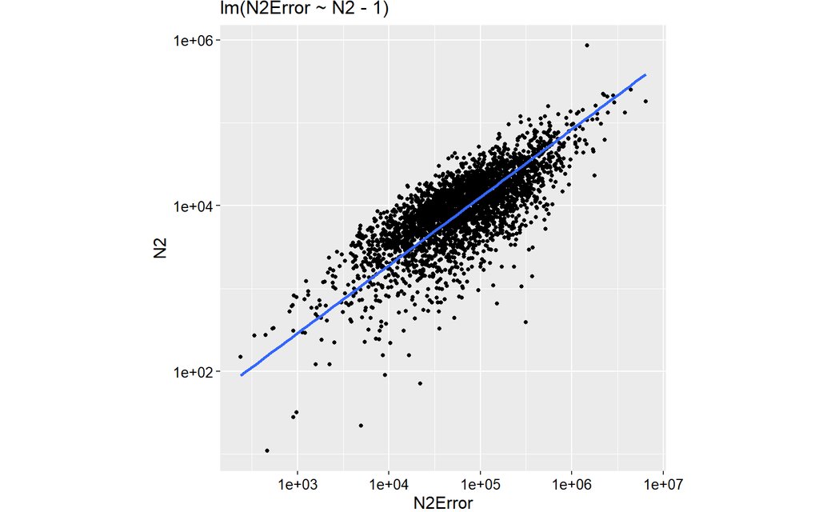

```r
N2ErrorN2Plot <- SimpleNErrorNModel(Independent="N2",Dependent="N2Error")
```

Below are the two versions of the smoothed data capturing different scales of its variations. The boxes are the concentration measured plus or minus the standard error. This gives some measure of how weighted the point is.

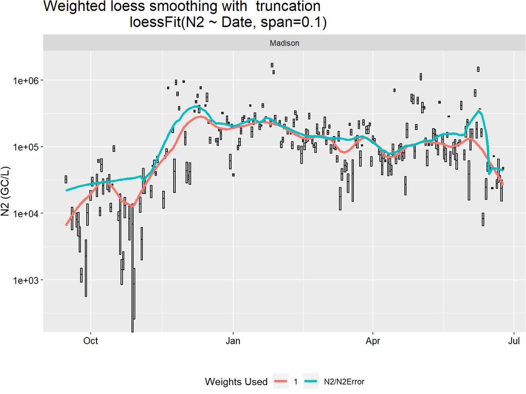

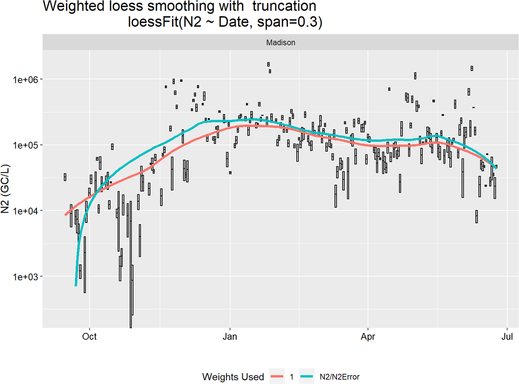

```r
LowSpanPlot <- LoessSmoothPlot(SiteS="Madison",Span=.1, weights=c("Constant","N/NSE"),
                               min=0,max=120)

HighSpanPlot <- LoessSmoothPlot(SiteS="Madison",Span=.3, weights=c("Constant","N/NSE"),
                                min=0,max=120)
```

This smoothing model offers similar residuals for N1 and N2 with the residuals agreeing after December. This indicates that the data is being cleaned and some older data points have greater day to day variation then the best sample of the filter.

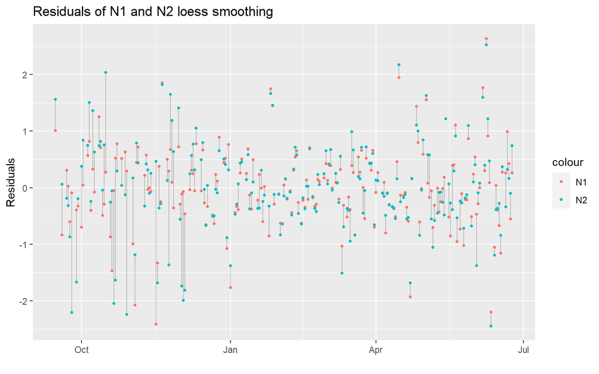

```r
MadLIMS%>%
  ggplot(aes(x=Date))+
  geom_segment(aes(y=ResidN1,yend=ResidN2,xend=Date),alpha=.2)+
  geom_point(aes(y=(ResidN1),color="N1"),size=1)+
  geom_point(aes(y=(ResidN2),color="N2"),size=1)+
  labs(title="Residuals of N1 and N2 loess smoothing",
       x="",y="Residuals")
```

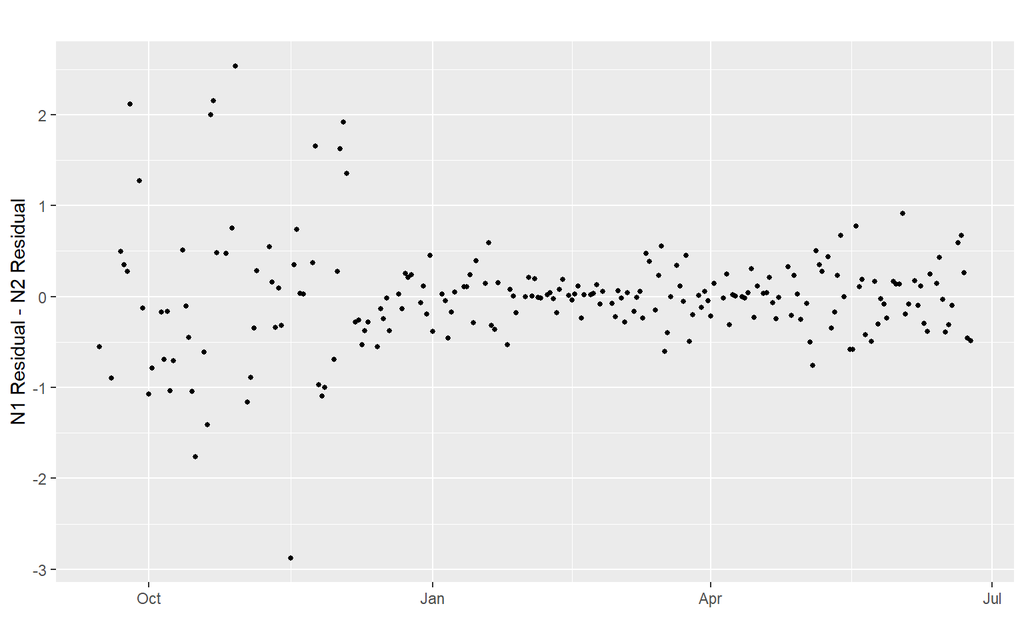

```r
MadLIMS%>%
  ggplot(aes(x=Date))+
  geom_point(aes(y=(ResidN1)-(ResidN2)),size=1)+
  labs(title="",
       x="",y="N1 Residual - N2 Residual")
```

This is method is extended for the interceptors. Data from before January is missing due to it not being in the LIMS system. older version of that data is not used because it is missing the standard error for N2 and includes data that has been reran

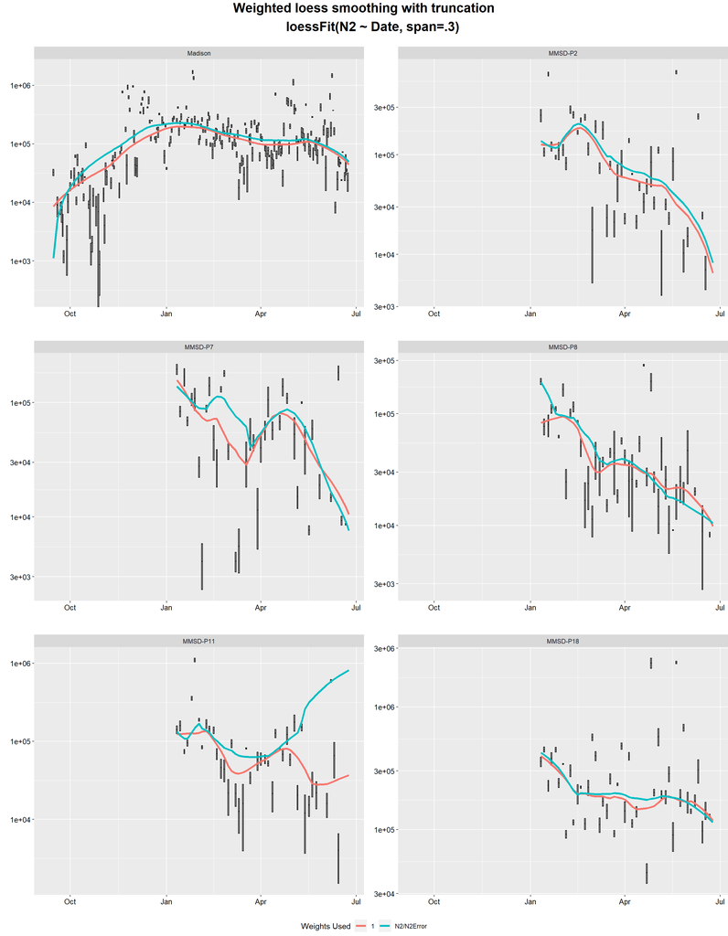

```r
MapList=lapply(c("Madison","MMSD-P2","MMSD-P7","MMSD-P8","MMSD-P11","MMSD-P18"),
               LoessSmoothPlot,
               Span=.3,max=20,weights=c("Constant","N/NSE"),
               Title=F,FullLim=T,NoLabel=T)
```

Also extended to UW data. This offers the clearest image that N2 has a wider distribution than cases.

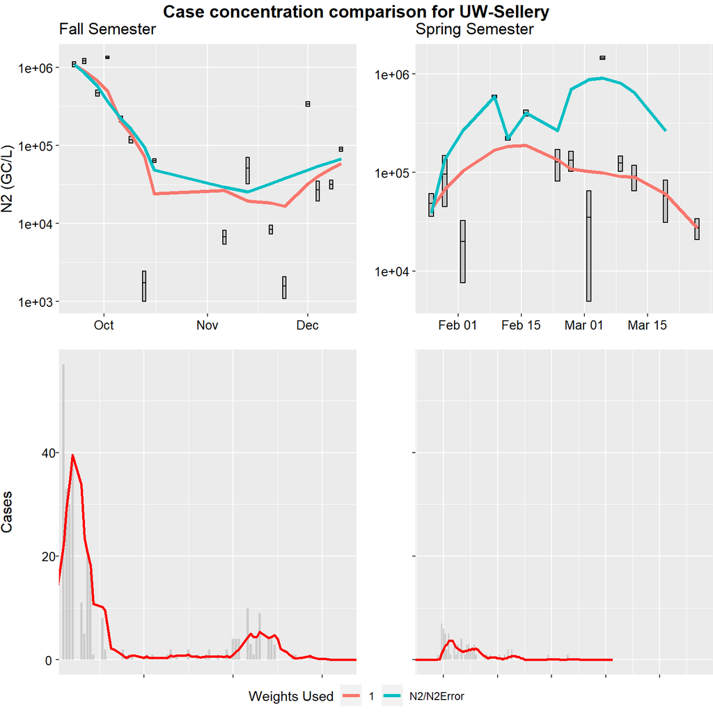

```r
N2CaseCompDorms(SiteS="UW-Sellery",Span=.5,Max=25,Weights=c("Constant","N/NSE"))
```

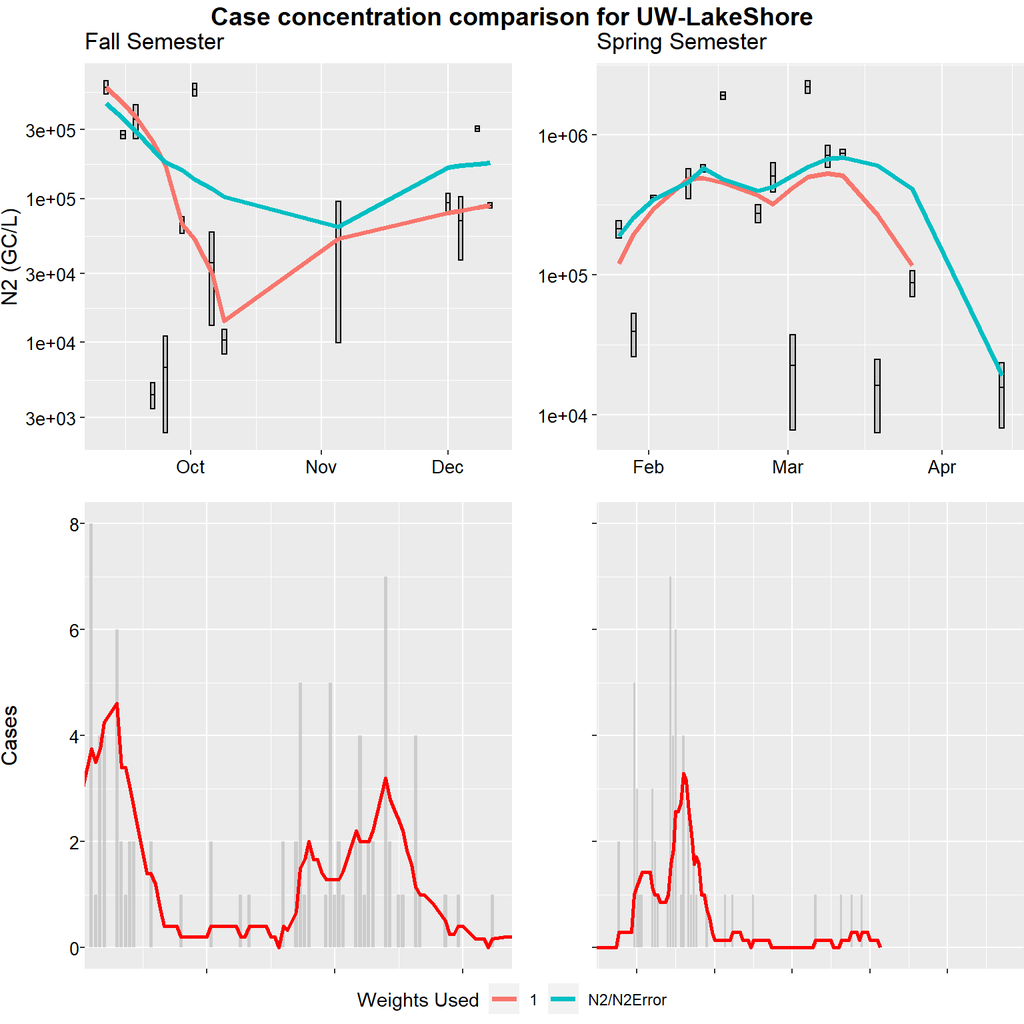

```r
N2CaseCompDorms(SiteS="UW-LakeShore",Span=.5,Max=25,Weights=c("Constant","N/NSE"))
```